# EdgeR

Большакова Анна 5030102/90401

Название пакета расшифровывается как анализ цифровой экспрессии генов в R.

Работает с целочисленными таблицами.

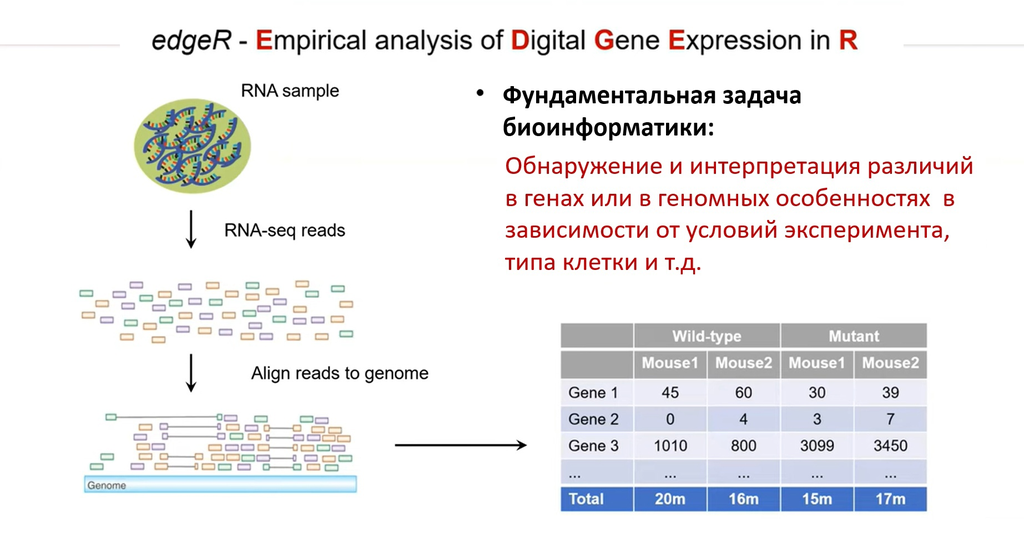

## Реализует ряд статистических методологий, основанных на отрицательных биномиальных распределениях, включая эмпирическую байесовскую оценку, точные тесты, обобщенные линейные модели и тесты квазиправдоподобия.

## Применяется для

## RNA-seq

## ChIP-seq

## ATACseq

## Bisulfite-seq

## SAGE

## CAGE

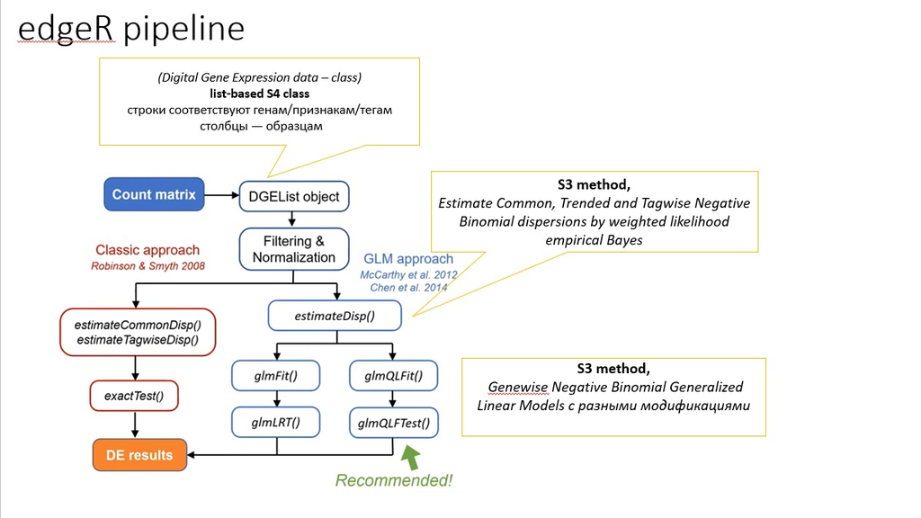

## Pipiline. Пример

Установка пакета:

```r
if (!require("BiocManager", quietly = TRUE))
    install.packages("BiocManager")
BiocManager::install("edgeR")
library(edgeR)
```

## 0. Чтение таблицы

```r
library(edgeR)
load("Counts.RData")
Counts <- tmp$counts
colnames(Counts) <- c("16N", "16T", "18N", "18T", "19N", "19T")
dim(Counts)
```

```
## [1] 25702     6
```

```r
head(Counts)
```

```
##           16N 16T 18N 18T 19N 19T
## 653635      0   1   0   1   0   0
## 100422834   0   0   0   0   0   0
## 645520      0   0   0   0   0   0
## 79501       0   0   0   0   0   0
## 729737      1   0   2   2   2   1
## 100507658   0   0   0   0   0   0
```

## 1. Create DGEList

!! Философия этого пакета заключается в том, что вся информация должна содержаться в одной переменной. Когда мы позже будем использовать функции из этого пакета, мы напишем что-то вроде d <- AssessmentCommonDisp(d), что, как мы обычно предположили бы, перезаписывает d. Вместо этого эта функция пропускает через функцию все, что уже было в d, но просто добавляет в список еще один элемент.

```r
dgList <- DGEList(counts=Counts, genes=rownames(Counts))

 dgList
```

```
## An object of class "DGEList"
## $counts
##           16N 16T 18N 18T 19N 19T
## 653635      0   1   0   1   0   0
## 100422834   0   0   0   0   0   0
## 645520      0   0   0   0   0   0
## 79501       0   0   0   0   0   0
## 729737      1   0   2   2   2   1
## 25697 more rows ...
##
## $samples
##     group lib.size norm.factors
## 16N     1  7682564            1
## 16T     1  6402930            1
## 18N     1  6275906            1
## 18T     1  8775887            1
## 19N     1  5624046            1
## 19T     1  7426932            1
##
## $genes
##               genes
## 653635       653635
## 100422834 100422834
## 645520       645520
## 79501         79501
## 729737       729737
## 25697 more rows ...
```

```r
# dgList$samples
# head(dgList$counts)
# head(dgList$genes)
```

## 2. Filtering

В этом наборе данных около 26000 генов. Однако многие из них не будут выражены или не будут представлено достаточным количеством прочтений, чтобы внести свой вклад в анализ. Удаление этих генов означает, что в конечном итоге мы имеем меньше тестов для выполнения, тем самым уменьшая проблемы, связанные с многократным тестированием. Здесь мы сохраняем только те гены которые представлены как минимум 1cpm (cpm=counts per million).

```r
countsPerMillion <- cpm(dgList) #S3 method, Compute counts per million (CPM) or reads per kilobase per million (RPKM)
summary(countsPerMillion)
```

```
##       16N                16T                18N                18T
##  Min.   :    0.00   Min.   :    0.00   Min.   :    0.00   Min.   :    0.00
##  1st Qu.:    0.00   1st Qu.:    0.00   1st Qu.:    0.00   1st Qu.:    0.00
##  Median :    0.78   Median :    2.50   Median :    0.80   Median :    1.94
##  Mean   :   38.91   Mean   :   38.91   Mean   :   38.91   Mean   :   38.91
##  3rd Qu.:    9.11   3rd Qu.:   22.80   3rd Qu.:    9.24   3rd Qu.:   22.79
##  Max.   :84286.70   Max.   :64373.19   Max.   :75536.19   Max.   :80210.01
##       19N                 19T
##  Min.   :     0.00   Min.   :    0.00
##  1st Qu.:     0.00   1st Qu.:    0.00
##  Median :     0.53   Median :    2.29
##  Mean   :    38.91   Mean   :   38.91
##  3rd Qu.:     6.58   3rd Qu.:   21.41
##  Max.   :104818.84   Max.   :57001.33
```

## 3. Normalization

```r
countCheck <- countsPerMillion > 1
head(countCheck)
```

```
##             16N   16T   18N   18T   19N   19T
## 653635    FALSE FALSE FALSE FALSE FALSE FALSE
## 100422834 FALSE FALSE FALSE FALSE FALSE FALSE
## 645520    FALSE FALSE FALSE FALSE FALSE FALSE
## 79501     FALSE FALSE FALSE FALSE FALSE FALSE
## 729737    FALSE FALSE FALSE FALSE FALSE FALSE
## 100507658 FALSE FALSE FALSE FALSE FALSE FALSE
```

```r
keep <- which(rowSums(countCheck) >= 2)
dgList <- dgList[keep,]
summary(cpm(dgList)) #compare this to the original summary
```

```
##       16N                16T                18N                18T
##  Min.   :    0.00   Min.   :    0.00   Min.   :    0.00   Min.   :    0.00
##  1st Qu.:    1.69   1st Qu.:    5.47   1st Qu.:    1.75   1st Qu.:    4.56
##  Median :    6.77   Median :   17.49   Median :    6.85   Median :   16.98
##  Mean   :   67.43   Mean   :   67.27   Mean   :   67.43   Mean   :   67.36
##  3rd Qu.:   22.91   3rd Qu.:   47.32   3rd Qu.:   23.90   3rd Qu.:   49.45
##  Max.   :84286.70   Max.   :64373.19   Max.   :75536.19   Max.   :80210.01
##       19N                 19T
##  Min.   :     0.00   Min.   :    0.00
##  1st Qu.:     1.24   1st Qu.:    5.12
##  Median :     4.80   Median :   16.56
##  Mean   :    67.44   Mean   :   67.32
##  3rd Qu.:    18.14   3rd Qu.:   44.30
##  Max.   :104818.84   Max.   :57001.33
```

## 4. Data Exploration

Мы можем изучить отношения между выборками, создав график на основе многомерного масштабирования.

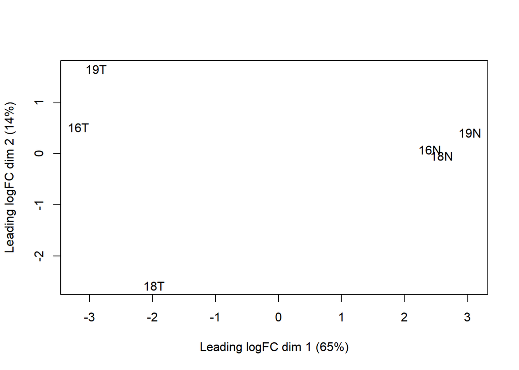

```r
plotMDS(dgList) # из пакета limma
```

## 5. Setting up the Model

Теперь мы готовы настроить модель! Сначала нам нужно указать нашу матрицу проекта, которая описывает настройку эксперимент.

```r
sampleType <- rep("N", ncol(dgList)) #N=normal; T=tumour
sampleType[grep("T", colnames(dgList))] <- "T"
sampleReplicate <- paste("S", rep(1:3, each=2), sep="")

designMat <- model.matrix(~sampleReplicate + sampleType)
designMat
```

```
##   (Intercept) sampleReplicateS2 sampleReplicateS3 sampleTypeT
## 1           1                 0                 0           0
## 2           1                 0                 0           1
## 3           1                 1                 0           0
## 4           1                 1                 0           1
## 5           1                 0                 1           0
## 6           1                 0                 1           1
## attr(,"assign")
## [1] 0 1 1 2
## attr(,"contrasts")
## attr(,"contrasts")$sampleReplicate
## [1] "contr.treatment"
##
## attr(,"contrasts")$sampleType
## [1] "contr.treatment"
```

## 6. Estimating Dispersion

Нам нужно оценить параметр дисперсии для нашей отрицательной биномиальной модели. Так как их всего несколько образцы, трудно точно оценить дисперсию для каждого гена, поэтому нам нужен способ «обмена» информацией между генами.

В edgeR мы используем эмпирический метод Байеса, чтобы «сжать» оценки генетической дисперсии до общей дисперсии. (tagwise dispersion)

```r
#s3 Estimates a common negative binomial dispersion parameter for a DGE dataset with a general experimental design.
dgList <- estimateGLMCommonDisp(dgList, design=designMat)
#s3 Estimates the abundance-dispersion trend by Cox-Reid approximate profile likelihood.
dgList <- estimateGLMTrendedDisp(dgList, design=designMat)
#s3 Compute an empirical Bayes estimate of the negative binomial dispersion parameter for each tag, with expression levels specified by a log-linear model.
dgList <- estimateGLMTagwiseDisp(dgList, design=designMat)
```

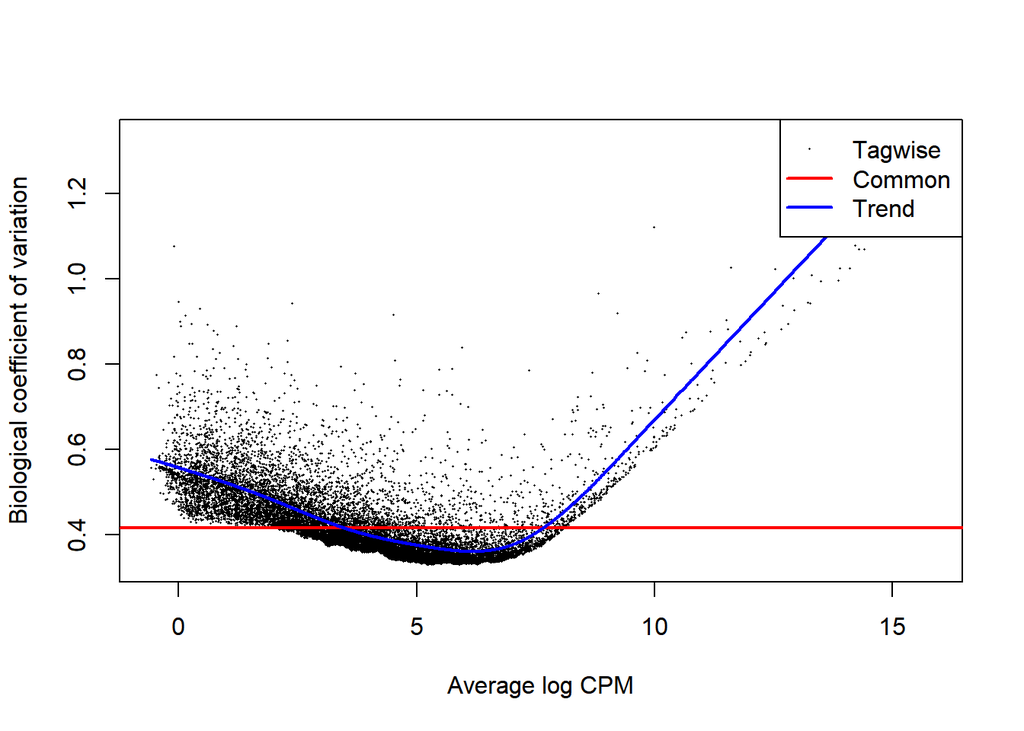

```r
plotBCV(dgList) #Plot the genewise biological coefficient of variation (BCV) against gene abundance (in log2 counts per million).
```

*The biological coefficient of variation (BCV) is the square root of the dispersion parameter in the negative binomial model.*

## 7.Differential Expression

```r
#s3 Fit a negative binomial generalized log-linear model to the read counts for each gene. Conduct genewise statistical tests for a given coefficient or coefficient contrast.
fit <- glmFit(dgList, designMat)
# Likelihood ratio tests for trend
lrt <- glmLRT(fit, coef=4)
```

Теперь мы можем найти наши дифференциально выраженные гены. После подгонки модели мы можем использовать функцию topTags() для изучения результатов и установить пороги для идентификации подмножеств дифференциально экспрессируемых генов.

```r
#Extracts the most differentially expressed genes (or sequence tags) from a test object, ranked either by p-value or by absolute log-fold-change.
edgeR_result <- topTags(lrt)
?topTags
```

```
## запускаю httpd сервер помощи... готово
```

Наконец, мы можем построить график логарифмических изменений всех генов и выделить те, которые экспрессируются по-разному.

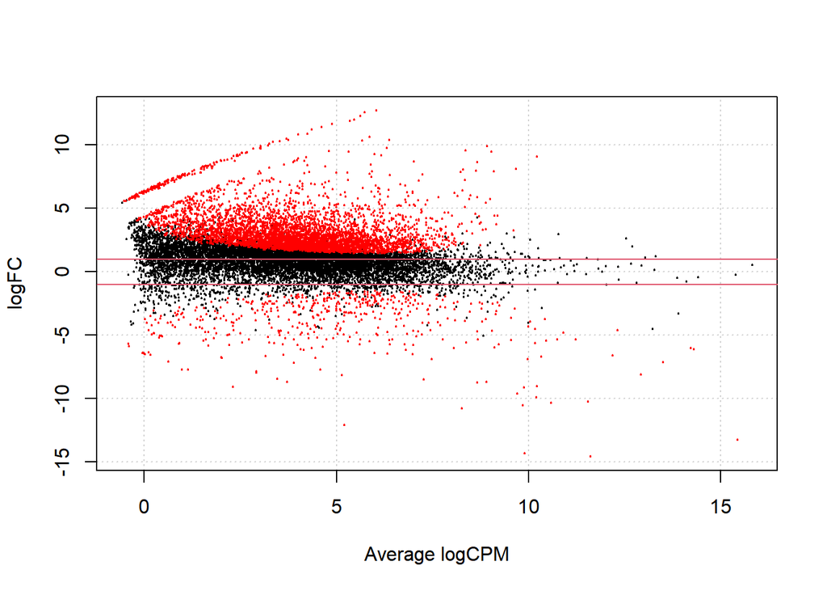

```r
?decideTests
#Identify which genes are significantly differentially expressed from an edgeR fit object containing p-values and test statistics.
deGenes <- decideTestsDGE(lrt, p=0.001)

deGenes <- rownames(lrt)[as.logical(deGenes)]
#Make a mean-difference plot of two libraries of count data with smearing of points with very low counts, especially those that are zero for one of the columns.
plotSmear(lrt, de.tags=deGenes)

abline(h=c(-1, 1), col=2)
```